# High End Corner Radar Users Guide

# Overview

This demo is a reference application to showcase the implementation of mmWave High-end Corner Radar using AWR2944. This demo assists in the development of software applications to meet NCAP R79 safety requirements.

# Requirements

## Hardware and Requirements

| Item | Details |
| --- | --- |
| Device | AWR2944 ES1.0 EVM |
| Computer | PC with Windows 7 or 10. If a laptop is used, please use the ‘High Performance’ power plan in Windows. |
| Micro USB Cable | 1x Micro USB cable for mmWave sensor. |
| Power Supply | 12V, >2A with 2.1-mm barrel jack (center positive). |

## Software Requirements

| Tool | Version | Required For | Download link |
| --- | --- | --- | --- |
| TI mmWave MCU+ SDK | 04.02.00.01 | Building the application, flashing the image | [Link](https://www.ti.com/tool/download/MMWAVE-MCUPLUS-SDK/04.02.00.01) |
| Python | 3.x | Flashing | [Link](https://www.python.org/downloads/) |
| Python Libraries: pyserial, xmodem, tqdm | Latest | Flashing | [pyserial](https://pypi.org/project/pyserial/), [xmodem](https://pypi.org/project/xmodem/), [tqdm](https://pypi.org/project/tqdm/) |
| Matlab Runtime | 8.5.1 | Lab GUI | [Link](https://in.mathworks.com/products/compiler/matlab-runtime.html) |
| Code Composer Studio | 11.0 | Rebuilding the Lab | [Link](https://www.ti.com/tool/CCSTUDIO) |

# Quickstart

The quickstart guide will cover setting up the EVM for flashing (UART boot mode) and functioning (QSPI boot mode), flashing the firmware, and running the demo.

## 1. Setup the EVM for UART Boot Mode (flashing mode)

Connect the EVM to the PC via a micro USB cable. For this lab, only the XDS_USB connector needs to be connected.

Now, set the EVM to UART boot mode to enable flashing. This is done by changing the SOP jumpers/switches to the settings specified by the following table:

| SOP0 Jumper/Switch | SOP1 Jumper/Switch | SOP2 Jumper/Switch | SOP0 Jumper/Switch |
| --- | --- | --- | --- |
| 1 | 1 | 0 | No-Boot Mode ROM does not execute in this bootmode. |
| 1 | 0 | 1 | UART Boot Mode ROM receives the secondary boot loader via UART interface MSS SCI A and loads it in SoC memory and switches to SBL execution. SBL receives multicore application image via UART interface… |
| 1 | 0 | 0 | QSPI Boot Mode ROM loads the SBL from serial flash at flash offset of 0x0, and SBL loads the multicore appimage from serial flash at flash offset of 0xA0000. |

After this, the EVM needs to be power cycled by pressing the NRESET button on the EVM for the SOP pins to latch.

## 2. Flash the EVM using SDK’s Python Script

To experiment with High End Corner Radar lab, an EVM with the corresponding image flashed is needed.

The following binary needs to be flashed to the EVM to start experimenting with the High End Corner Radar lab. These binaries have been pre-built for ease of use.

| Platform | BIN Name | Location |
| --- | --- | --- |
| AWR2944 | awr2944_corner_radar.appimage | `<LAB_LOC>/Prebuilt_binaries/` |

Install Python 3.x and the libraries mentioned in the software requirements section of this document. For usage of the script, refer to the mmWave MCU+ SDK User Guide section: 4.2 “How to flash an image onto mmWave EVM”.

To identify the correct COM port number to be used, go to the Device Manager window on you PC. Under ports, the ports corresponding to AWR2944 EVM should appear as:

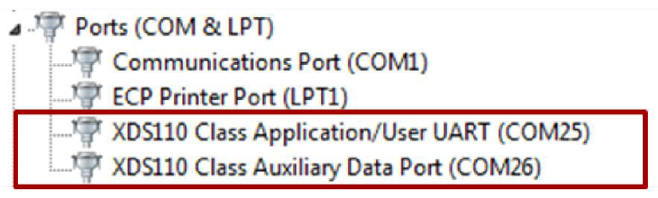

Once flashing completes, set EVM to QSPI Boot Mode as per Table 1. to execute application flashed.

## 3. Setup the EVM for QSPI Mode

Set the SOP jumpers/switches to configuration corresponding to QSPI boot mode as per the table in section 1. After this, power cycle the device by pressing the NRESET button on the EVM.

## 4. Running the Lab

- Once the image has been flashed onto the device, and the device is booted in QSPI boot mode, the device can be connected to the High End Corner Radar visualizer (`<LAB_DIR>/gui/High_end_corner_radar_ti_design_visualization.exe`) running on PC via the XDS USB cable.
- The High End Corner Radar GUI needs the User and Auxiliary Data Port COM port of the device. This can be found from the device manager panel in Windows.

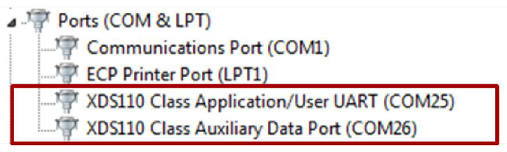

- Once the COM ports have been entered in the GUI configuration screen, the High End Corner Radar GUI will open a subsequent screen (GUI display screen) and start to display the data . Data starts streaming from the device as soon as it is brought out of reset (no CLI commands need to be sent over UART for transmission to start). The visualizer GUI will start plotting this data. The following figures show screenshots of the GUI:  
  **GUI Configuration screen**

[figure not shown]

**GUI Display screen**

[figure not shown]

For more details on the functionality offered by the GUI, refer to the developer guide.

## Appendix

- Refer Release Notes for limitation and known issues.
- Refer Developer’s Guide for details of the design of this lab, and how to rebuild this lab.

# Developer’s Guide

## Overview

The High End Corner Radar lab has been made as an extension of the Out of Box Demo in the mmWave MCU+ SDK 4.2. In particular, the lab uses the OOB demo based on the SDK DDMA (Doppler Division Multiple Access) data processing chain as the base. The DDMA chain is used to meet the requirements for the high end corner radar, particularly the maximum velocity and range.

The `<LIB_DIR>/src/demo` folder corresponds to the OOB demo from the SDK. Modifications have been made to this demo. Briefly, they involve:

1. Adding group tracker (gtrack) to the processing chain. Gtrack runs on the MSS.
2. Adding RANSAC (see TI Design document for details) to the processing chain. RANSAC runs on the MSS. RANSAC is responsible for filtering out stationary objects in the pointcloud before sending this data to the group tracker. Since the sensor itself is in motion, this is not a trivial task, hence the need for RANSAC. The RANSAC filter is also exported to over UART to the GUI. The GUI will draw each point as smaller/larger depending on the RANSAC filter.
3. Parallelizing the MSS and DSS operation. When DSS has processed frame i upto the pointcloud, the MSS will start processing frame i. During this, if the next frame, frame i+1 starts being acquired, the DSS is capable of processing it in parallel. This is necessary to meet the timing requirements.
4. Disabling range CFAR. The SDK’s DDMA chain uses CFAR along two dimensions: range and doppler. We have disabled the second range CFAR to obtain a richer pointcloud.
5. Since targets from the group tracker have to be displayed, and the pointcloud points will be larger/smaller based on the RANSAC filter being exported, a GUI has been developed in Matlab to handle this. This GUI is packaged with the lab.

Apart from this, the datapath was modified subtly from the SDK datapath. If the lab uses a modified SDK component, it has been packaged with the lab in the /src/ folder (both source and compiled library). This is done so that the SDK installation doesn’t need to be modified to rebuild the lab. As the lab will use any modified dependencies from its own src/ folder, it is self-contained in this regard.

## Rebuild Application & Tool

1. Using makefiles to rebuild the High End Corner Reflector lab:
   - If the source in `<LAB_DIR>/alg/` or `<LAB_DIR>/datapath/` folders has been modified, perform step 2 of this section before this step. Otherwise, proceed with this section.
   - Install GNU make (gmake) from MinGW or other equivalent methods, set the PATH environment variable to ensure it can be called form the command prompt. This can be installed with MinGW.
   - Open command prompt to `<MMWAVE_SDK_INSTALL_PATH>\scripts\windows` path.
   - Set required device type in setenv.bat for the lab (awr2944)  
     `set MMWAVE_SDK_DEVICE=awr2944`
   - Run setenv.bat in command prompt which should set environment variables for the mmWave build environment.
   - In the same command prompt screen, navigate to the folder containing the targeted makefile. use “gmake all” command in `<LAB_DIR>/src/demo/`
2. Using Makefiles to rebuild High End Corner Radar dependency components (only needed if these components have been modified):
   - Install GNU make (gmake) from MinGW or other equivalent methods, set the PATH environment variable to ensure it can be called form the command prompt. This can be installed with MinGW.
   - Open command prompt to `<MMWAVE_SDK_INSTALL_PATH>\scripts\windows` path.
   - Set required device type in setenv.bat for the lab (awr2944)  
     `set MMWAVE_SDK_DEVICE=awr2944`
   - Run setenv.bat in command prompt which should set environment variables for the mmWave build environment.
   - In the same command prompt screen, navigate to the folder containing the targeted makefile. use “gmake all” command in the following directories:
     - `<LAB_DIR>/src/alg/gtrack/`
     - `<LAB_DIR>/src/datapath/dpu/rangeprocDDMA`
     - `<LAB_DIR>/src/datapath/dpc/dpu/dopplerprocDDMA`
   - These components need not be rebuilt to rebuild the lab using CCS (provided they haven’t been modified by the user).

## Directory Structure

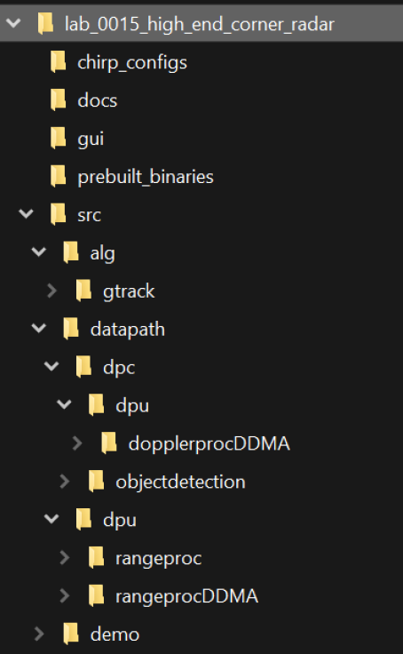

This lab contains multiple components. The /src/ folder contains the following four components:

1. Gtrack
2. dopplerprocDDMA DPU
3. rangeprocDDMA DPU
4. demo (High End Corner Radar demo)

## Configurations through CLI

Similar to the out of box demo, the High End Corner Radar lab is highly configurable via the use of CLI commands sent to the device over the user UART COM port. When the lab powers on, a default configuration (corresponding to the file `<LAB_DIR>/chirp_configs/profile_r79.cfg`) will be applied immediately, and the device will start transmitting data over UART.

The user can reconfigure the lab for a different .cfg file by sending an appropriate .cfg file through the GUI. This is an optional step.

As the lab is an extension of the out of box demo, most of the commands in the .cfg file correspond to the commands used in the out of box demo. For details on the individual commands and usages, please refer to the SDK user guide.

The High End Corner Radar lab implements a few new commands in the configuration file. The following table gives details on these commands:

| Command | Usage | Description |
| --- | --- | --- |
| gtrack | `gtrack <enable> <maxNumPoints> <maxNumTracks> <initialRadialVelocity> <maxRadialVelocity> <radialVelocityResolution> <maxAcceleration0> <maxAcceleration1> <maxAcceleration2> <deltaT> <boresightFilter… | This command enables/disables the group tracker, and configures it with the appropriate configuration if enabled. Before calling this command, the following commands must be called: appSceneryParams, … |
| appSceneryParams | `appSceneryParams <sensorPosX> <sensorPosY> <sensorPosZ> <orientationAzim> <orientationElev> <bBoxX1> <bBoxX2> <bBoxY1> <bBoxY2> <bBoxZ1> <bBoxZ2>` | This command populates the GTRACK_sceneryParams structure. This is one of the advanced parameter structures passed to the gtrack module. |
| appGatingParams | `appGatingParams <gain> <limitsArr0> <limitsArr1> <limitsArr2> <limitsArr3>` | This command populates the GTRACK_gatingParams structure. This is one of the advanced parameter structures passed to the gtrack module. |
| appStateParams | `appStateParams <det2actThre> <det2freeThre> <active2freeThre> <static2freeThre> <exit2freeThre> <sleep2freeThre>` | This command populates the GTRACK_stateParams structure. This is one of the advanced parameter structures passed to the gtrack module. |
| appAllocParams | `appAllocParams <snrThre> <snrThreObscured> <velocityThre> <pointsThre> <maxDistanceThre> <maxVelThre>` | This command populates the GTRACK_allocationParams structure. This is one of the advanced parameter structures passed to the gtrack module. |
| ransac | `ransac <enable> <iterations> <thresh>` | This command is used to configure the RANSAC algorithm. The algorithm is used to split the pointcloud into a set of points moving/stationary. For details on this, refer to the TI Design document for H… |
| rangeCfar | `rangeCfar <enable>` | This command enables/disables the CFAR along range direction. This is disabled by default in the lab. |

## UART data TLV Formats

The High End Corner Radar Lab outputs data over UART in TLV format (Type, Length, Value) packets. For exhaustive details of this process, refer to the source code, particularly the MmwDemo_transmitProcessedOutput function in `LAB_DIR/src/demo/mss/mss_main.c`.

The rest of this section gives brief details of this format.

The following TLV formats are used in the High End Corner Radar Lab:

| TLV Type | C Structure | Description |
| --- | --- | --- |
| 1 (MMWDEMO_OUTPUT_MSG_DETECTED_POINTS) | DPIF_PointCloud Cartesian | Contains the pointcloud detected for a particular frame. |
| 7 (MMWDEMO_OUTPUT_MSG_DETECTED_POINTS_SIDE_INFO) | DPIF_PointCloudSideInfo | Contains the sideInfo for the corresponding pointcloud detected for a particular frame. i’th entry in this array (TLV body) correspoinds to the i’th entry in the type 1 TLV array. |
| 10 (MMWDEMO_OUTPUT_MSG_TRACKER) | MmwDemo_tracker_out | Contains the acquired tracks for this frame. Each track corresponds to a target being tracked by the group tracker. This TLV contains information about the position, velocity and acceleration of the t… |
| 11 (MMWDEMO_OUTPUT_MSG_RANSAC_FILTER_MASK) | uint8_t | Contains the TLV mask for the corresponding pointcloud detected in this frame. i’th entry here corresponds to the i’th entry in type 1 TLV. If i’th field in this mask is 0, it means the i’th point in … |

## Chirp Configuration

```
The lab uses the following chirp configuration:
```

| PARAMETER | CONFIGURATION |
| --- | --- |
| Idle Time (us) | 5 |
| ADC start time (us) | 5 |
| Ramp end time (us) | 18.83 |
| Number of ADC samples | 384 |
| Frequency slope (MHz/us) | 8.883 |
| MIMO (1 → yes) | 1 |
| Number of chirps per profile | 768 |
| Effective chirp time (us) | 23.83 |
| Bandwidth (MHz) | 114 |
| Frame length (ms) | 250 |

## High End Corner Reflector Lab GUI

This visualizer plots the X-Y plot, Y-Z plot and Range-Doppler plot with tracker in X-Y and Range-Doppler plot. The GUI in this visualizer can be used to select the Application Port and the Data Port, send configuration file to the AWR2944 device connected, select the maximum dimensions in the x, y and z direction along with maximum velocity. Some other features which the GUI supports is the recording of data by selecting the corresponding filename and also supports replaying of the recorded file later.

The dots on the visualizer represent the points from the scene captured by the radar and the tracker (if enabled) appears across the scene in form of “diamond” shape if it is tracked as an object by the radar. By default, the GUI plots X-Y plot along with tracker whereas other plots could be disabled if user thinks it’s not necessary.

### GUI Options

The GUI offers the following options:

1. **UART Port Options:** In this portion of the GUI, user has to put the corresponding port numbers from Device Manager->COM ports.
2. **Config file Options:** In this section of the GUI, the user can choose to send the Configuration file through the user UART port by checking the checkbox and then browsing and selecting the corresponding .cfg file. This is optional.
3. **GUI options:** In this section, the user can select the maximum dimensions in the x, y and z direction along with the maximum velocity. The values present in the GUI by default is based on the tests done internally.
4. **Record & Replay options:** In this section, the user has the ability to choose either record/replay options and not both of them together. For the recording option, the user has to check the box and browse to choose the file directory and enter the filename [It’s best to give a filename with extension “.dat”, for e.g like record1.dat]. For the replay option, the user has to check the box, and browse and select the corresponding filename.
5. **Display checkbox options:** Visualizer on getting started has two checkboxes – one to select the Doppler-Range plot and other to select the Y-Z plot. In case the user does not have the ability to run high end graphics from his end, he can uncheck them so as to get the X-Y plot and its tracker streamlined properly.